# Simulation Studies of Test Equating

September 04, 2019

### Technical Decision Points

- Simulation platform
- Platform to estimate ability from simulated datasets
  - Estimation method
- Metric for comparing different simulation scenarios

### Simulation Sanity Check

- Should be able to recreate ability metric of simulated item-level dataset in a single sample
  - Flat Bland-Altmann plot - (estimated ability - true ability)/true ability
    - Dispersion around 0 line consistent with expected standard error of measurement
  - Simulation parameters
    - 30 dichotomous items
    - item difficulty equaly spaced from -3 to +3
    - item discrimination all 2.0
    - sample size = 500
    - theta simulated from N(0,1)

### Test Information of Simulated Sanity Check Test

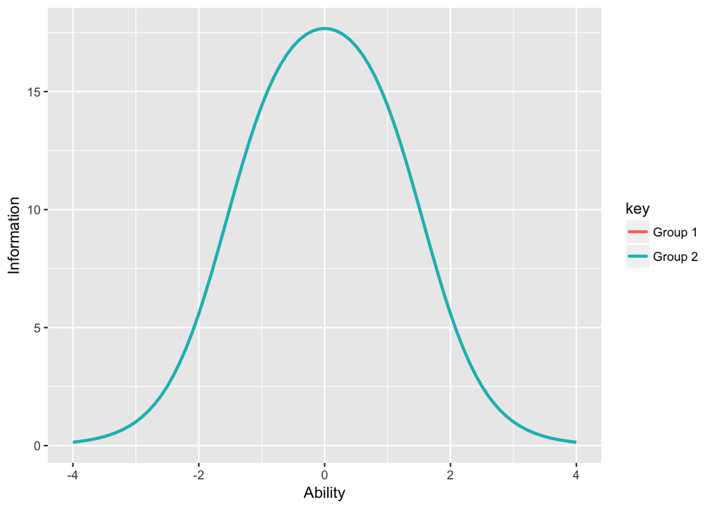

### Sanity Check 1 - R psych simulation, ability estimated with Mplus, factor score method = EAP

ability_est mean = 0.01371  
ability_est sd = 0.9079856  
rmse = 0.310084

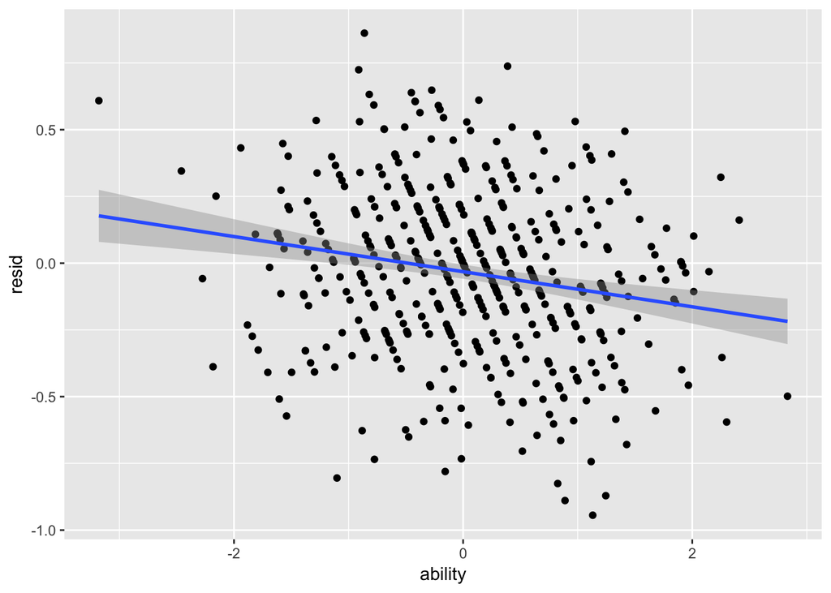

### Sanity Check 2 - R psych simulation, ability estimated with Mplus, factor score method = plausible values

ability_est mean = 0.011574  
ability_est sd = 0.9324693  
rmse = 0.332668

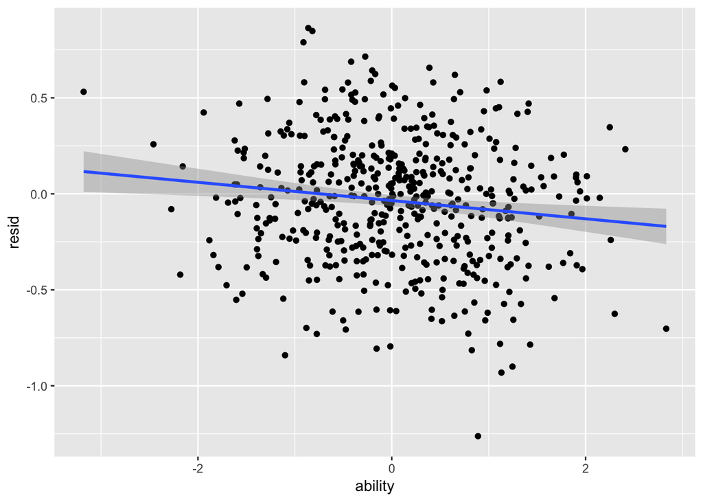

### Sanity Check 3 - R mirt simulation and estimation of ability, factor score method = plausible values

ability_est mean = -0.0176419  
ability_est sd = 1.0210325  
rmse = 0.3648712

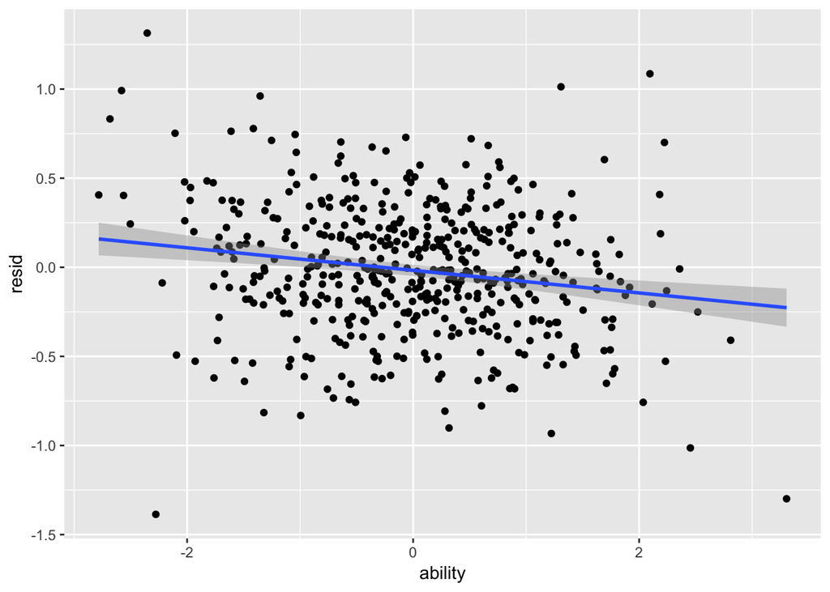

### Sanity Check 4 - R mirt simulation and estimation of ability, factor score method = EAP

ability_est mean = -0.0015932  
ability_est sd = 0.9735515  
rmse = 0.2531648

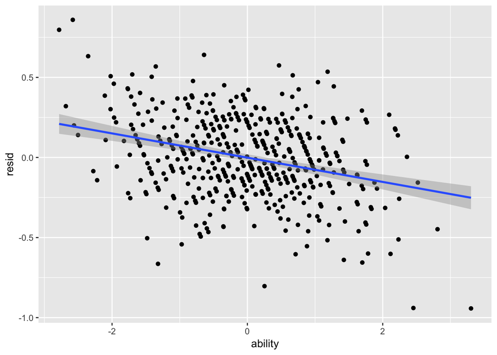

### Sanity Check 5 - R mirt simulation and estimation of ability, factor score method = ML

ability_est mean = -0.0189053  
ability_est sd = 0.9758648  
rmse = 0.2594486

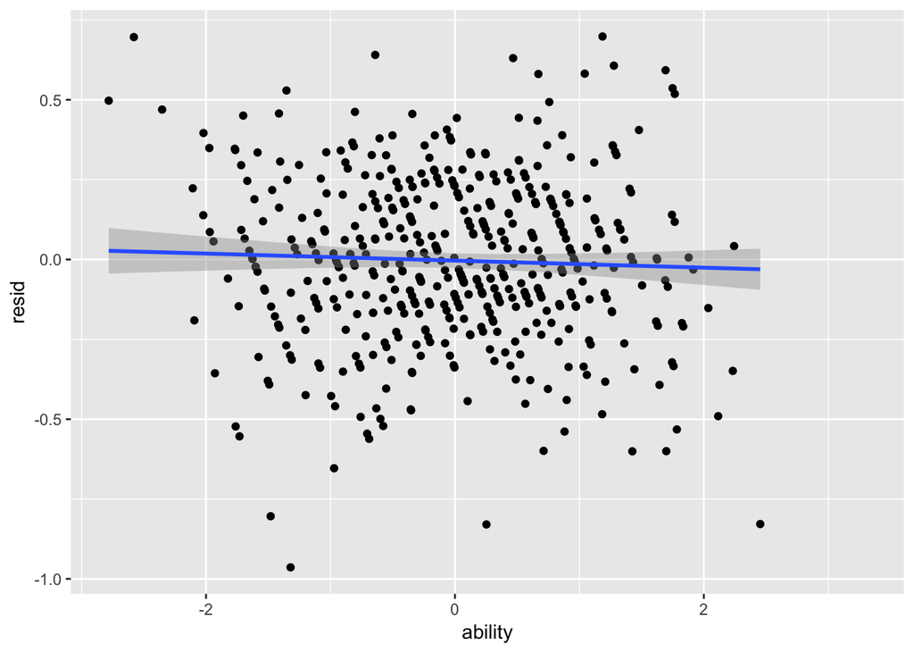

### Recommendations

- R mirt for simulation and estimation
  - Common platform for both components
  - Accomodates dichotomous and polytomous items
- RMSE as metric for comparing scenarios
- Ability score estimation method has tradeoffs
  - plausible values best in reproducing true ability metric
    - greater dispersion around true ability (RMSE)
  - EAP has low dispersion around true ability
    - more shrinkage of estimated ability metric, though may be acceptable
  - ML reproduces metric and has low dispersion around true ability
    - estimated abilityis not defined for cases with all correct or all incorrect responses -Should we consider transforming estimated ability scale to 0,1 metric?

### HRS TICS Information (immediate and delayed word list recall included)

info_all - all items including immediated word recall and delayed word recall are included  
info_no_dr - all items except delayed word recall are included  
info_no_ir - all items except immediated word recall are included

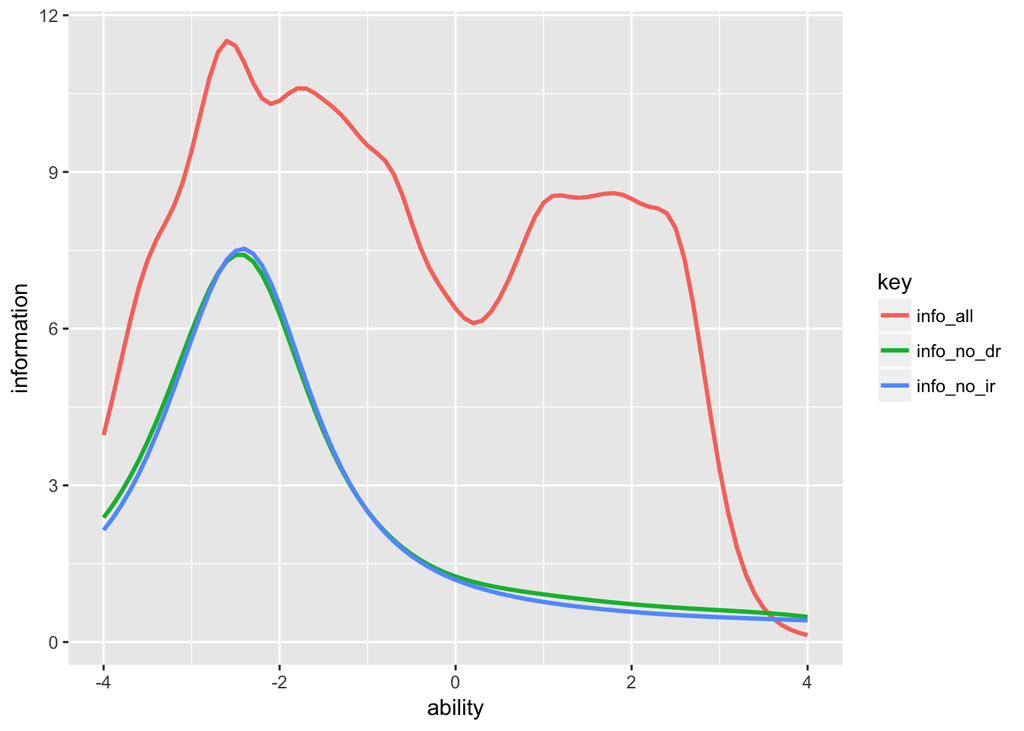

Note. Information values for all items included in model over estimate true information values due to unidimensionality and local independence assumptions not being met in this model.

### MHAS TICS Information (all items included)

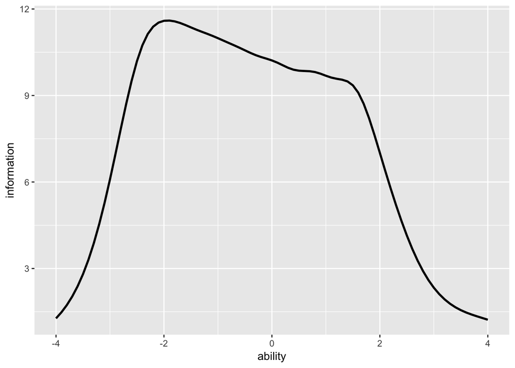

Note. Information values for all items included in model over estimate true information values due to unidimensionality and local independence assumptions not being met in this model.

### Combined HRS and MHAS TICS Information (all items included)

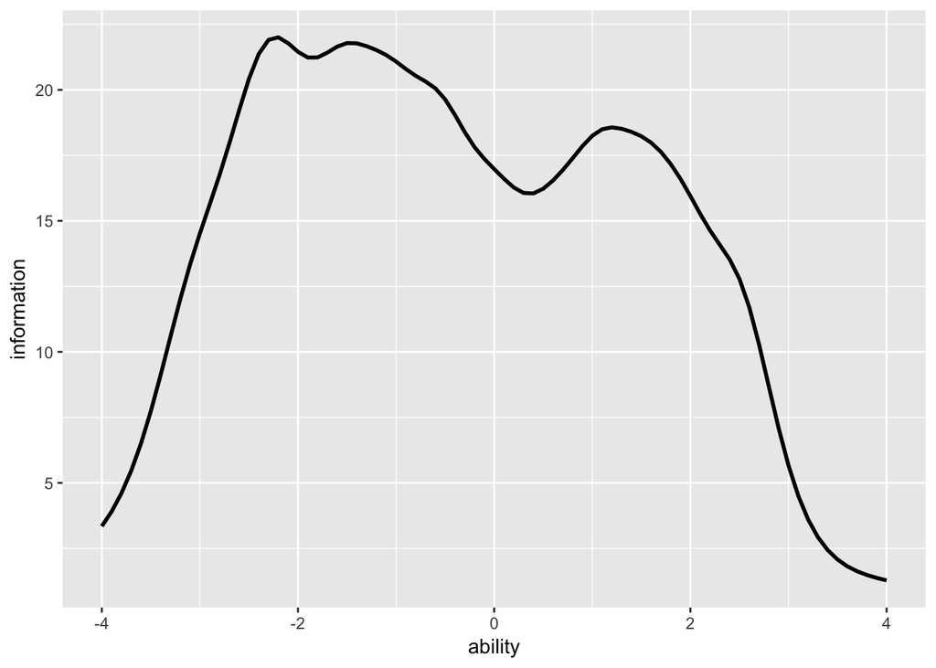

Note. Information values for all items included in model over estimate true information values due to unidimensionality and local independence assumptions not being met in this model.

### HRS TICS Item Parameters (all items included)

```
## $UBAK
##        a1     d g u
## par 1.051 3.541 0 1
##
## $UDAT
##        a1     d g u
## par 0.727 1.859 0 1
##
## $UDAY
##        a1     d g u
## par 1.546 4.777 0 1
##
## $UDWR
##        a1    d1    d2    d3   d4   d5     d6     d7     d8      d9
## par 3.943 10.58 6.736 4.822 2.74 0.57 -3.837 -5.903 -7.878 -10.004
##
## $UIWR
##        a1     d1    d2    d3    d4   d5     d6    d7     d8    d9
## par 3.703 12.973 9.113 7.046 4.986 2.84 -1.852 -4.19 -6.608 -9.04
##
## $UMON
##        a1     d g u
## par 1.591 4.987 0 1
##
## $UNM1
##        a1     d g u
## par 1.014 5.423 0 1
##
## $UNM2
##        a1     d g u
## par 1.344 3.384 0 1
##
## $UNM5
##        a1     d g u
## par 1.642 4.703 0 1
##
## $UNM6
##        a1   d g u
## par 1.013 2.4 0 1
##
## $USUB
##        a1    d1    d2    d3   d4     d5
## par 0.614 3.284 1.919 1.308 0.61 -0.289
##
## $UYER
##        a1     d g u
## par 2.144 5.496 0 1
##
## $GroupPars
##     MEAN_1 COV_11
## par      0      1
```

### MHAS TICS Item Parameters (all items included)

```
## $UDAY
##        a1     d g u
## par 0.882 1.319 0 1
##
## $UFCO2
##       a1    d1   d2
## par 0.98 2.612 1.18
##
## $UFRE1
##        a1    d1     d2
## par 0.921 0.103 -1.344
##
## $UMON
##        a1     d g u
## par 1.465 3.283 0 1
##
## $UVSC
##        a1    d1    d2    d3    d4     d5     d6     d7     d8     d9
## par 1.175 3.237 2.167 1.185 0.362 -0.354 -0.992 -1.596 -2.175 -2.869
##
## $UWD
##        a1    d1    d2    d3    d4    d5     d6    d7     d8
## par 3.139 7.232 6.267 4.971 3.336 1.527 -0.537 -2.84 -5.151
##
## $UWR1
##        a1    d1    d2    d3   d4     d5     d6     d7     d8
## par 1.847 5.062 3.614 1.924 0.25 -1.421 -3.165 -5.182 -7.377
##
## $UWR2
##        a1    d1    d2    d3    d4   d5     d6    d7     d8
## par 2.767 7.516 6.346 4.673 2.641 0.58 -1.535 -3.75 -6.005
##
## $UWR3
##        a1    d1    d2    d3    d4    d5    d6    d7     d8
## par 3.124 7.601 6.923 5.668 3.972 2.072 0.013 -2.26 -4.577
##
## $UYER
##        a1    d g u
## par 1.515 2.43 0 1
##
## $GroupPars
##     MEAN_1 COV_11
## par      0      1
```

### Combined HRS and MHAS TICS Item Parameters (all items included)

```
## $UBAK
##        a1     d g u
## par 1.139 3.393 0 1
##
## $UDAT
##        a1     d g u
## par 0.774 1.744 0 1
##
## $UDAY
##        a1     d g u
## par 1.077 2.264 0 1
##
## $UDWR
##        a1    d1    d2   d3    d4    d5     d6     d7     d8    d9
## par 4.207 9.947 6.126 4.24 2.185 0.027 -4.415 -6.514 -8.528 -10.7
##
## $UIWR
##        a1     d1    d2    d3    d4    d5    d6     d7     d8     d9
## par 3.944 12.242 8.456 6.432 4.417 2.308 -2.37 -4.733 -7.189 -9.664
##
## $UMON
##        a1     d g u
## par 1.643 4.027 0 1
##
## $UNM1
##        a1     d g u
## par 1.119 5.287 0 1
##
## $UNM2
##        a1     d g u
## par 1.473 3.195 0 1
##
## $UNM5
##        a1     d g u
## par 1.799 4.471 0 1
##
## $UNM6
##        a1     d g u
## par 1.097 2.249 0 1
##
```

[output cut: 24 more lines]

```
## $UWR1
##        a1    d1  d2   d3    d4    d5     d6     d7     d8
## par 1.791 5.244 3.8 2.11 0.434 -1.24 -2.985 -5.001 -7.194
##
## $UWR2
##       a1    d1    d2    d3    d4    d5     d6     d7     d8
## par 2.65 7.704 6.559 4.908 2.892 0.845 -1.255 -3.452 -5.686
##
## $UWR3
##        a1   d1    d2    d3    d4    d5    d6     d7     d8
## par 2.973 7.79 7.126 5.894 4.224 2.348 0.314 -1.931 -4.217
##
## $GroupPars
##     MEAN_1 COV_11
## par      0      1
```

### Simulate item response dataset using item parameters from combined HRS and MHAS data

```r
# This chunk show code to create one simulated item response dataset based on empirically
# estimated parameters from and IRT analysis of the combined HRS and MHAS samples
theta1 <- data.frame(rnorm(500,0.5,1))
  names(theta1) <- "theta1"
  theta1$group <- "HRS"
  theta2 <- data.frame(rnorm(500,-0.5,1))
  names(theta2) <- "theta1"
  theta2$group <- "MHAS"
  theta1 <- rbind(theta1,theta2)


  ds2 <- data.frame(simdata(N=1000, model=hrmecal, Theta=as.matrix(theta1$theta1)))

  ds2 <- cbind(theta1,ds2)

  m1hrme <- mirt.model('cog = 1-19')
  hm_par <- mirt(ds2[,3:21],m1hrme,pars='values')

  hmcal <- mirt(ds2[,3:21],m1hrme,pars=hm_par)
```

[output not shown]

[output cut: 10 more lines]

[output not shown]

```r
  # coef(hmcal)
```